# Model

Updated: 2018-08-03

This Document will provide an overview for many different statistical analyses that can be done in R. The intricacies of each of these methods will need to be further explored but this will provide you with a starting point.

## Linear Regression

Linear Regression is a model fitting method which attempts to prdict an value, usually numeric (i.e. brokerage) using one or more explanitory variables (i.e. day of week, distance, truck bill).

### Basic Regression

For our examples, we will be using the `mtcars` dataset which is built into R. This dataset is very common and has several numeric variables about vehicles. They are:

```r
names(mtcars)
```

```
 [1] "mpg"  "cyl"  "disp" "hp"   "drat" "wt"   "qsec" "vs"   "am"   "gear" "carb"
```

if we preview the first 10 rows of data, we can get a better sense for what we are dealing with.

```r
head(mtcars,10)
```

|  | mpg | cyl | disp | hp | drat | wt | qsec | vs | am | gear | carb |
| --- | --- | --- | --- | --- | --- | --- | --- | --- | --- | --- | --- |
| Mazda RX4 | 21.0 | 6 | 160.0 | 110 | 3.90 | 2.620 | 16.46 | 0 | 1 | 4 | 4 |
| Mazda RX4 Wag | 21.0 | 6 | 160.0 | 110 | 3.90 | 2.875 | 17.02 | 0 | 1 | 4 | 4 |
| Datsun 710 | 22.8 | 4 | 108.0 | 93 | 3.85 | 2.320 | 18.61 | 1 | 1 | 4 | 1 |
| Hornet 4 Drive | 21.4 | 6 | 258.0 | 110 | 3.08 | 3.215 | 19.44 | 1 | 0 | 3 | 1 |
| Hornet Sportabout | 18.7 | 8 | 360.0 | 175 | 3.15 | 3.440 | 17.02 | 0 | 0 | 3 | 2 |
| Valiant | 18.1 | 6 | 225.0 | 105 | 2.76 | 3.460 | 20.22 | 1 | 0 | 3 | 1 |
| Duster 360 | 14.3 | 8 | 360.0 | 245 | 3.21 | 3.570 | 15.84 | 0 | 0 | 3 | 4 |
| Merc 240D | 24.4 | 4 | 146.7 | 62 | 3.69 | 3.190 | 20.00 | 1 | 0 | 4 | 2 |
| Merc 230 | 22.8 | 4 | 140.8 | 95 | 3.92 | 3.150 | 22.90 | 1 | 0 | 4 | 2 |
| Merc 280 | 19.2 | 6 | 167.6 | 123 | 3.92 | 3.440 | 18.30 | 1 | 0 | 4 | 4 |

you can also learn more about this dataset by typing `help(mtcars)` into the console.

Now, after receiving this information, our first hypothesis might be that an increase in engine displacement (`disp`) would tend to indicate a decrease in fuel efficiency (`mpg`). To determine whether or not this hypothesis holds significant statistical value, we can perform a linear regression. We do this with the following command:

```r
lmcars <- summary(lm(mpg~disp, data = mtcars))
lmcars
```

```
Call:
lm(formula = mpg ~ disp, data = mtcars)

Residuals:
    Min      1Q  Median      3Q     Max
-4.8922 -2.2022 -0.9631  1.6272  7.2305

Coefficients:
             Estimate Std. Error t value Pr(>|t|)
(Intercept) 29.599855   1.229720  24.070  < 2e-16 ***
disp        -0.041215   0.004712  -8.747 9.38e-10 ***
---
Signif. codes:  0 ‘***’ 0.001 ‘**’ 0.01 ‘*’ 0.05 ‘.’ 0.1 ‘ ’ 1

Residual standard error: 3.251 on 30 degrees of freedom
Multiple R-squared:  0.7183,    Adjusted R-squared:  0.709
F-statistic: 76.51 on 1 and 30 DF,  p-value: 9.38e-10
```

The results above tell us several things. First, the formula of the linear regression is printed again. Then, we recive basic statistics about our residuals. Residuals are basically the variance between your actual data and your predicted data. The smaller your variance, the better your model. After the residual statistics, we receive information about the coeeficients. Here we are interested in several things.

1. Is `disp` a significant predictor of `mpg`?
2. What change in `mpg` is effected by a 1-unit change in `disp` (i.e. slope of our regression line)?
3. What is the y-intercept of our regression line?

Now that we have answered all three of our questions. We can say with statistical confidence that **yes**, an increase in `disp` will tend to indicate a decrease in `mpg`. The equation for this regresssion relationship is
$$mpg = -0.0412(disp) + 29.60$$

### Model Variable Selection

While this analysis might be sufficient for quick estimation of `mpg`, we have several more variables available to us that could potentially provide a more accurate estimation. While we could add all of the variables into the equation and gain a very accurate equation, this method is not very flexible or practical at scale. Therefore, we need to select which variables are important enough to keep. This is the processs of variable selection.

A common method for variable selection is stepwise selection. In this method you can take several paths:

1. [Simple Model] Start with one explanatory variable and add on one at a time until it no longer explains a significant amount of variation
2. [Complex Model] Start with all of the explanatory variables and remove one at a time until all variables explain a significant amount of variation
3. Do both at the same time and compare the results

The key values when doing stepwise model selection are the AIC/BIC values as well as the adjusted r-square value of the model as a whole. The goal in finding a good model is to minimize the AIC/BIC value and to maximize the r-square value.

If we return to our `mtcars` dataset, we can use this strategy to determine a better model for estimating `mpg`.

As a reminder, our dataset contains several numeric variables: mpg, cyl, disp, hp, drat, wt, qsec, gear, carb and two indicator variables: vs, am. Within the numeric values, `cyl`, `gear`, and `carb` are discrete variables and will be ignored. For now, we will just try to use the continuous numeric values to predict `mpg` for ease of interpretation. Additionally, since `qsec` is not really a characteristic of the car but rather a performance metric, we will leave it out of our analysis as well.

Our first attempt will be to fit the model in a backwards fashion. This will generally maintain a maximum accuracy at the cost of increased complexity. As you can see below, the step function evaluates a model object (`model1`). It tests the full model first and then removes variables that don’t significantly explain a change in `mpg` until it ends up at the “best” model.

```r
model1 <- lm(mpg~disp+hp+drat+wt, data = mtcars)
step(model1, direction = 'backward')
```

```
Start:  AIC=65.77
mpg ~ disp + hp + drat + wt

       Df Sum of Sq    RSS    AIC
- disp  1     0.844 183.68 63.919
<none>              182.84 65.772
- drat  1    12.153 194.99 65.831
- hp    1    60.916 243.75 72.974
- wt    1    70.508 253.35 74.209

Step:  AIC=63.92
mpg ~ hp + drat + wt

       Df Sum of Sq    RSS    AIC
- drat  1    11.366 195.05 63.840
<none>              183.68 63.919
- hp    1    85.559 269.24 74.156
- wt    1   107.771 291.45 76.693

Step:  AIC=63.84
mpg ~ hp + wt

       Df Sum of Sq    RSS    AIC
<none>              195.05 63.840
- hp    1    83.274 278.32 73.217
- wt    1   252.627 447.67 88.427

Call:
lm(formula = mpg ~ hp + wt, data = mtcars)

Coefficients:
(Intercept)           hp           wt
   37.22727     -0.03177     -3.87783
```

In this case, the best model is determined to be `mpg ~ hp + wt` this means that even though we found `disp` to be a significant predictor of `mpg` in our simple regression equation, the combination of `hp` and `wt` actually offers “better” predictive power.

In order to run the model *foreward* we need to do a few extra steps. The first is to reduce the dataset to only the 5 variables we will need. The next step is to build a null model (model with no predictor variables) and a full model (the starting model of our previous method). These are what define the scope of our forward stepwise regression.

```r
mtcarsSlim <- mtcars[,c(1,3:6)]
model2_null <- lm(mpg~1,data = mtcarsSlim)
model2_full <- lm(mpg~., data = mtcarsSlim)
step(model2_null, scope = list(lower = model2_null,upper = model2_full), direction = 'forward')
```

```
Start:  AIC=115.94
mpg ~ 1

       Df Sum of Sq     RSS     AIC
+ wt    1    847.73  278.32  73.217
+ disp  1    808.89  317.16  77.397
+ hp    1    678.37  447.67  88.427
+ drat  1    522.48  603.57  97.988
<none>              1126.05 115.943

Step:  AIC=73.22
mpg ~ wt

       Df Sum of Sq    RSS    AIC
+ hp    1    83.274 195.05 63.840
+ disp  1    31.639 246.68 71.356
<none>              278.32 73.217
+ drat  1     9.081 269.24 74.156

Step:  AIC=63.84
mpg ~ wt + hp

       Df Sum of Sq    RSS    AIC
<none>              195.05 63.840
+ drat  1   11.3659 183.68 63.919
+ disp  1    0.0571 194.99 65.831

Call:
lm(formula = mpg ~ wt + hp, data = mtcarsSlim)

Coefficients:
(Intercept)           wt           hp
   37.22727     -3.87783     -0.03177
```

From the output above you notice that the model starts with just the intercept. Then, it adds `wt`, then `hp` to arrive at the final model which happens to be the same as our first method. While the results are not *always* the same, it is common.

Finally, we will run the stepwise linear regression from both ends for good measure. This will essentially run both of these previous tests simultaneously and return the “best” model. Since both forward and backward selection returned the same model, we can expect this final method to be the same.

```r
step(model1, direction = 'both')
```

```
Start:  AIC=65.77
mpg ~ disp + hp + drat + wt

       Df Sum of Sq    RSS    AIC
- disp  1     0.844 183.68 63.919
<none>              182.84 65.772
- drat  1    12.153 194.99 65.831
- hp    1    60.916 243.75 72.974
- wt    1    70.508 253.35 74.209

Step:  AIC=63.92
mpg ~ hp + drat + wt

       Df Sum of Sq    RSS    AIC
- drat  1    11.366 195.05 63.840
<none>              183.68 63.919
+ disp  1     0.844 182.84 65.772
- hp    1    85.559 269.24 74.156
- wt    1   107.771 291.45 76.693

Step:  AIC=63.84
mpg ~ hp + wt

       Df Sum of Sq    RSS    AIC
<none>              195.05 63.840
+ drat  1    11.366 183.68 63.919
+ disp  1     0.057 194.99 65.831
- hp    1    83.274 278.32 73.217
- wt    1   252.627 447.67 88.427

Call:
lm(formula = mpg ~ hp + wt, data = mtcars)

Coefficients:
(Intercept)           hp           wt
   37.22727     -0.03177     -3.87783
```

As we predicited, the final model **is** the same as before. Knowing this, we can run a simple linear regression again to compare our values from earlier:

```r
(lm1 <- summary(lm(mpg~disp, data = mtcars)))
```

```
Call:
lm(formula = mpg ~ disp, data = mtcars)

Residuals:
    Min      1Q  Median      3Q     Max
-4.8922 -2.2022 -0.9631  1.6272  7.2305

Coefficients:
             Estimate Std. Error t value Pr(>|t|)
(Intercept) 29.599855   1.229720  24.070  < 2e-16 ***
disp        -0.041215   0.004712  -8.747 9.38e-10 ***
---
Signif. codes:  0 ‘***’ 0.001 ‘**’ 0.01 ‘*’ 0.05 ‘.’ 0.1 ‘ ’ 1

Residual standard error: 3.251 on 30 degrees of freedom
Multiple R-squared:  0.7183,    Adjusted R-squared:  0.709
F-statistic: 76.51 on 1 and 30 DF,  p-value: 9.38e-10
```

```r
(lm2 <- summary(lm(mpg~hp+wt, data=mtcars)))
```

```
Call:
lm(formula = mpg ~ hp + wt, data = mtcars)

Residuals:
   Min     1Q Median     3Q    Max
-3.941 -1.600 -0.182  1.050  5.854

Coefficients:
            Estimate Std. Error t value Pr(>|t|)
(Intercept) 37.22727    1.59879  23.285  < 2e-16 ***
hp          -0.03177    0.00903  -3.519  0.00145 **
wt          -3.87783    0.63273  -6.129 1.12e-06 ***
---
Signif. codes:  0 ‘***’ 0.001 ‘**’ 0.01 ‘*’ 0.05 ‘.’ 0.1 ‘ ’ 1

Residual standard error: 2.593 on 29 degrees of freedom
Multiple R-squared:  0.8268,    Adjusted R-squared:  0.8148
F-statistic: 69.21 on 2 and 29 DF,  p-value: 9.109e-12
```

With a good understanding of our models from a numeric standpoint, let’s review a few key figures. First, lets take a look at the first model with the regression equation plotted. We can do this with plotting functions built into R as such:

```
only using the first two of 8 regression coefficients
```

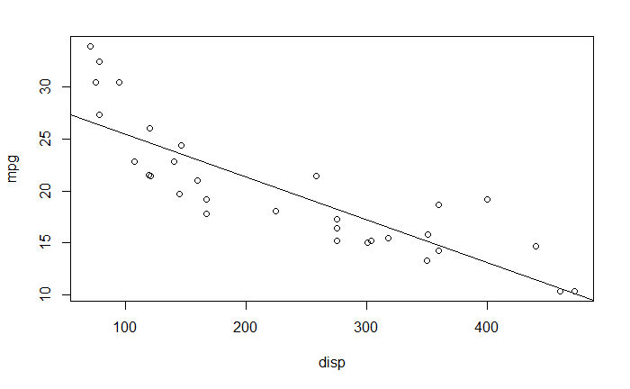

```r
plot(mpg~disp, data = mtcars)
abline(lm1)
```

However, many users of R agree that the `ggplot2` package offers many desirable plotting functions and therefore is used quite frequently. if we want to build the same figure in `ggplot2` syntax, we do the following:

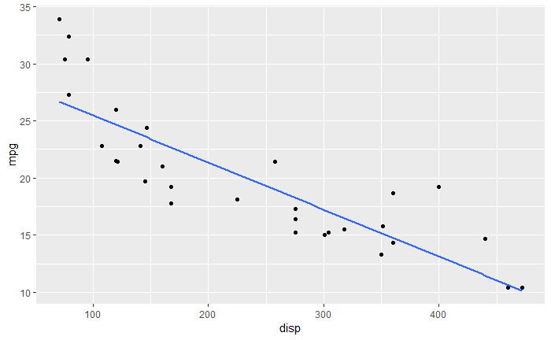

```r
library(ggplot2)
ggplot(mtcars, aes(disp,mpg)) +
  geom_point() +
  geom_smooth(method = 'lm', se = F)
```

You will notice that using `ggplot2` prevents you from having to build a linear model first. Instead, you can just use the geom_smooth() option. `ggplot2` can be confusing at first but there are several good resources out there, including [their own documentation](https://ggplot2.tidyverse.org/reference/).

The fundamental difference between the built-in plotting functions and `ggplot2` is that the base R function builds layered immages and ggplot2 builds one cohesive image file. This makes the base functions arguably more flexible because each layer doesn’t care about what’s in the other layers. However, it also means that there is potential for unintentional plotting of incorrect information. I encourage you to try both and experience where each method excels.

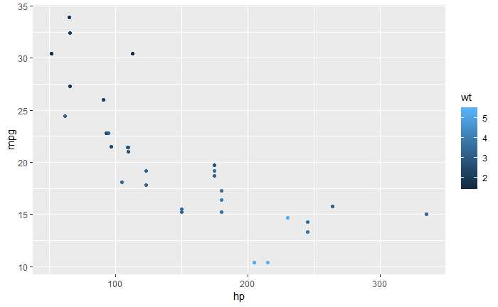

```r
ggplot(mtcars, aes(hp,mpg, color = wt)) +
  geom_point()
```

The next option is to plot the values in three dimensional space. For this we will need another package called `plotly`

```r
require(plotly)
plot_ly(mtcars, x= ~wt, y = ~hp, z = ~mpg) %>%
  add_markers()
```

[interactive chart not shown]